CÂMARA MUNICIPAL DE PORTO VELHO  
Sistema de Apoio ao Processo Legislativo

# Lei-DL nº 3.413, de 17 de abril de 2026

Identificação Básica

Tipo de Texto Articulado

Norma Jurídica

Tipo da Norma Jurídica

Lei

Número

3413

Ano

2026

Data

17 de Abril de 2026

Ementa

Dispõe sobre a criação do Programa Bolsa-Atleta no Município de Porto Velho, denominado como Bolsa Atleta Time Esporte Porto Velho, e dá outras providências

O **PREFEITO DO MUNICÍPIO DE PORTO VELHO** usando da atribuição que lhe é conferida no inciso IV, do artigo 87, da Lei Orgânica do Município de Porto Velho.

Faço saber que a **CÂMARA MUNICIPAL DE PORTO VELHO** aprovou e eu sanciono a seguinte

**LEI:**

CAPÍTULO I

**DAS DISPOSIÇÕES PRELIMINARES**

Art. 1º.

Fica instituído, no âmbito da Secretaria Municipal de Turismo, Esporte e Lazer – SEMTEL, o Programa Bolsa-Atleta Time Esporte Porto Velho, com a finalidade de estimular o desenvolvimento do desporto de base, educacional e de rendimento no Município de Porto Velho.

CAPÍTULO II

**DOS OBJETIVOS, DAS MODALIDADES E DAS CONDIÇÕES GERAIS**

Seção I

**Dos objetivos**

Art. 2º.

São objetivos do Programa Bolsa-Atleta Time Esporte Porto Velho:

I –

fomentar o desenvolvimento do esporte de base, educacional e de rendimento no Município;

II –

conceder incentivo, por meio de repasse financeiro, para a formação e o desenvolvimento contínuo de atletas, paratletas, surdoatletas, atletas-guia e técnicos; e

III –

promover inclusão social e diversidade no esporte, por meio de benefícios.

Seção II

Das modalidades de benefício

Art. 3º.

O Programa Bolsa-Atleta Time Esporte Porto Velho consiste na concessão de incentivo financeiro, na forma de bolsa, em prestações mensais, nas seguintes modalidades:

I –

Bolsa-Atleta, destinada a subsidiar o desempenho de atletas, paratletas, surdoatletas e atletas-guia praticantes do desporto de base, educacional e de rendimento, em modalidades olímpicas, paralímpicas e surdolímpicas, individuais ou coletivas, nas seguintes categorias:

a)

Atleta Estudantil, destinada a estudantes na faixa etária de 11 (onze) a 25 (vinte e cinco) anos, indicados pelo Governo do Estado de Rondônia, por intermédio da secretaria responsável pelo desporto educacional, por entidade do desporto escolar e/ou universitário, que tenham participado, no ano imediatamente anterior, de competições estaduais dos jogos escolares e/ou universitários de Rondônia ou de competições em nível nacional realizadas pela Confederação Brasileira do Desporto Escolar - CBDE, Confederação Brasileira do Desporto Universitário - CBDU, Comitê Olímpico do Brasil - COB, Comitê Paralímpico do Brasil - CPB ou Confederação Brasileira Desportos de Surdos - CBDS, compreendendo:

1

atletas que obtiveram a 1ª (primeira) colocação em modalidade individual ou que tenham sido selecionados entre os 3 (três) melhores atletas de modalidade coletiva correspondente, no evento estadual; e

2

atletas que obtiveram da 1ª (primeira) à 3ª (terceira) colocação em modalidade individual ou que tenham sido selecionados entre os 3 (três) melhores atletas de modalidade coletiva correspondente, no evento nacional;

b)

Atleta Base, destinada a atletas de 11 (onze) a 17 (dezessete) anos que tenham participado, no ano imediatamente anterior, da principal competição prioritária, observada a ordem nacional, regional e estadual, realizada pela federação esportiva estadual ou por confederação brasileira reconhecida pelo COB, CPB ou CBDS, compreendendo os que obtiveram classificação mínima de 1ª (primeira) a 3ª (terceira) colocação nas modalidades individuais ou coletivas, e, nas modalidades coletivas, tenham sido selecionados entre os 3 (três) melhores atletas correspondentes, nos eventos regional ou nacional, e os que obtiveram 1ª (primeira) colocação nos eventos estaduais;

c)

Atleta Estadual, destinada a atletas de 14 (catorze) a 28 (vinte e oito) anos, admitida idade mínima de 11 (onze) anos para a modalidade de ginástica rítmica, que tenham participado da principal competição estadual do calendário das federações esportivas estaduais filiadas a confederações nacionais reconhecidas pelo COB, CPB ou CBDS, compreendendo os atletas que obtiverem 1ª (primeira) colocação em modalidade individual ou que tenham sido selecionados entre os 3 (três) melhores atletas da modalidade coletiva correspondente;

d)

Atleta Nacional, destinada a atletas de 14 (catorze) a 28 (vinte e oito) anos que tenham participado do evento máximo regional ou nacional da temporada e obtido da 1ª (primeira) à 3ª (terceira) colocação em modalidade individual ou que tenham sido selecionados entre os 3 (três) melhores atletas da modalidade coletiva correspondente, em eventos de entidades esportivas nacionais reconhecidas pelo COB, CPB ou CBDS;

e)

Atleta Internacional, destinada a atletas de 14 (catorze) a 28 (vinte e oito) anos que tenham participado do evento máximo internacional da temporada e obtido da 1ª (primeira) à 3ª (terceira) colocação em modalidades individuais, em eventos internacionais oficiais indicados por entidades esportivas nacionais reconhecidas pelo COB, CPB ou CBDS e, quando couber, pela CBDE e CBDU.

II –

Bolsa-Técnico, destinada aos técnicos dos beneficiários da Bolsa Atleta, na forma desta Lei.

§ 1º

Os valores da Bolsa-Atleta e da Bolsa-Técnico constam do Anexo Único desta Lei.

§ 2º

O Poder Executivo poderá reajustar anualmente os valores previstos no Anexo Único desta Lei, observada a disponibilidade orçamentária e financeira fixada na Lei Orçamentária Anual e em seus créditos adicionais.

§ 3º

A quantidade anual de beneficiários da Bolsa-Atleta e da Bolsa Técnico será definida por ato da SEMTEL, observado o limite orçamentário e financeiro fixado na Lei Orçamentária Anual e em seus créditos adicionais, previamente planejados pelo órgão responsável pelo orçamento municipal.

§ 4º

É vedada a concessão de mais de uma bolsa do Programa ao mesmo atleta, paratleta, surdoatleta, atletaguia ou técnico.

§ 5º

Para os paratletas beneficiados, será admitida a concessão de bolsa a 1 (um) atleta-guia (atletismo) ou tapper (natação), no valor equivalente a 50% (cinquenta por cento) do benefício do paratleta nas categorias Nacional e Internacional, observados os critérios e quantitativos definidos em regulamento.

§ 6º

Consideram-se modalidades olímpicas, paralímpicas e surdolímpicas aquelas integrantes do programa dos Jogos Olímpicos, Paralímpicos e Surdolímpicos, reguladas, respectivamente, pelo Comitê Olímpico Internacional - COI, Comitê Paralímpico Internacional - IPC e Comitê Internacional de Esportes para Surdos ICSD, e administradas no Brasil por entidades filiadas, reconhecidas ou vinculadas ao COB, CPB e CBDS.

§ 7º

A concessão das bolsas não gera vínculo jurídico de qualquer natureza entre os beneficiários e a Administração Pública Municipal.

§ 8º

As bolsas não alcançam atletas pertencentes às categorias master ou similares.

§ 9º

É permitida a cumulação das bolsas com outras bolsas e benefícios de outras esferas públicas ou programas de incentivo ao ensino, à pesquisa, à iniciação científica e à extensão, inclusive para matriculados em cursos de graduação ou pósgraduação stricto sensu.

§ 10

Excepcionalmente, na categoria Atleta Estudantil, serão considerados aptos atletas e equipes de modalidades esportivas sem chancela olímpica, desde que tenham integrado o programa de competições dos eventos nacionais realizados pela CBDE, CBDU ou CPB no ano anterior ao pleito.

Seção III

**Dos requisitos gerais de habilitação**

Art. 4º.

Para se tornar beneficiário do Programa, o interessado deverá atender:

I –

para concessão e manutenção da Bolsa-Atleta:

a)

residir no Município de Porto Velho há, no mínimo, 1 (um) ano;

b)

enquadrar-se como atleta, paratleta, surdoatleta ou atleta-guia praticante do desporto de base, educacional ou de rendimento, em modalidades reconhecidas pelo COB, CPB ou CBDS;

c)

possuir registro válido nas entidades estaduais e/ou nacionais de administração e de prática do desporto no Estado de Rondônia, para as categorias previstas nas alíneas “a”, “c”, “d” e “e” do inciso I do art. 3º desta Lei;

d)

na categoria Atleta Estudantil, estar regularmente matriculado em instituição de educação básica ou superior, reconhecida pelo Ministério da Educação; e

e)

comprovar o preenchimento dos requisitos específicos da categoria pretendida, conforme arts. 6º a 10 desta Lei.

**Parágrafo único**.A comprovação de residência no Município de Porto Velho poderá ser dispensada para atleta, paratleta, surdoatleta ou atleta-guia convocado para integrar seleção brasileira, quando exigida permanência em outra unidade federativa, desde que permaneça filiado à federação esportiva rondoniense da respectiva modalidade, chancelada por entidade nacional reconhecida pelo COB, CPB ou CBDS, mediante prova documental.

II –

para concessão e manutenção da Bolsa-Técnico:

a)

residir e atuar profissionalmente no Município de Porto Velho há, no mínimo, 1 (um) ano;

b)

estar registrado e ativo perante o Conselho Regional de Educação Física – CREF;

c)

atuar como técnico de beneficiário das categorias Bolsa-Atleta Base, Nacional e Internacional; e

d)

exercer a função de técnico esportivo da respectiva modalidade há, no mínimo, 1 (um) ano.

§ 1º

Os beneficiários da categoria Atleta Estudantil deverão dedicar-se prioritariamente aos estudos e à prática esportiva, ressalvada a participação em programas de incentivo ao mercado de trabalho, qualificação profissional, pesquisa e extensão.

§ 2º

Para os fins desta Lei, os paratletas serão classificados em deficiência intelectual, física e visual, sem distinção de prioridade para fins de contemplação.

§ 3º

Os surdoatletas serão representados por sua respectiva associação ou órgão legalmente constituído.

Seção IV

**Da proteção à maternidade**

Art. 5º.

Fica assegurado às atletas, paratletas, surdoatletas, atletas-guia e técnicas, gestantes ou puérperas, inclusive em caso de adoção, o respeito à maternidade e aos direitos correlatos, no âmbito do Programa.

§ 1º

Na impossibilidade de comprovação de participação em competições no ano imediatamente anterior ao pedido, em razão de gestação ou puerpério, poderá ser considerado o resultado esportivo obtido no ano anterior ao afastamento.

§ 2º

É garantido o recebimento regular das parcelas mensais até a retomada da atividade esportiva, acrescido de até 6 (seis) meses após o nascimento.

§ 3º

Retomada a atividade esportiva ou encerrado o prazo do § 2º deste artigo, voltam a ser exigidas as obrigações assumidas no Programa.

§ 4º

O disposto neste artigo não impede que a beneficiária, com orientação médica e de seu treinador, continue ou retome a atividade esportiva.

CAPÍTULO III

**DOS REQUISITOS ESPECÍFICOS POR CATEGORIA**

Art. 6º.

Para a concessão da Bolsa-Atleta na categoria Atleta Estudantil, além do art. 4º desta Lei, exige-se:

I –

idade entre 11 (onze) e 25 (vinte e cinco) anos completos no ano da concessão;

III –

matrícula regular em instituição pública ou privada reconhecida pelo Ministério da Educação;

IV –

comprovação de plena atividade esportiva, por documentos e/ou registros fotográficos;

V –

participação em fases estaduais dos jogos escolares ou universitários de Rondônia, ou competições estaduais reconhecidas por CBDE, CBDU ou CPB;

VI –

para validação nacional, que o evento tenha sido realizado e/ou organizado por CBDE, CBDU, COB ou CPB; e

VII –

classificação mínima prevista na alínea “a” do inciso I do art. 3º desta Lei.

Art. 7º.

Para a concessão da Bolsa-Atleta na categoria Atleta Base, além do art. 4º desta Lei, exige-se:

I –

idade entre 11 (onze) e 17 (dezessete) anos completos no ano da concessão;

II –

autorização dos pais ou responsável legal, quando menor de 18 (dezoito) anos;

III –

matrícula regular em instituição de ensino reconhecida pelo Ministério da Educação;

IV –

comprovação de plena atividade esportiva, por documentos e/ou registros fotográficos;

V –

filiação à federação esportiva rondoniense da respectiva modalidade, chancelada por entidade nacional reconhecida;

VI –

participação em competições regionais e nacionais da modalidade;

VII –

participação, no ano imediatamente anterior, da principal competição regional ou nacional da categoria; e

VIII –

classificação mínima prevista na alínea “b” do inciso I do art. 3º desta Lei.

Art. 8º.

Para a concessão da Bolsa-Atleta na categoria Atleta Estadual, além do art. 4º desta Lei, exige-se:

I –

idade entre 14 (catorze) e 28 (vinte e oito) anos completos no ano da concessão, ressalvada a ginástica rítmica;

II –

autorização dos pais ou responsável legal, quando menor de 18 (dezoito) anos;

III –

matrícula regular, quando aplicável;

IV –

filiação à federação esportiva rondoniense chancelada por entidade nacional reconhecida;

V –

comprovação de plena atividade esportiva, por documentos e/ou registros fotográficos;

VI –

participação, no ano anterior, em competições estaduais do calendário oficial; e

VII –

classificação mínima prevista na alínea “c” do inciso I do art. 3º desta Lei.

Art. 9º.

Para a concessão da Bolsa-Atleta na categoria Atleta Nacional, além do art. 4º desta Lei, exige-se:

I –

idade entre 14 (catorze) e 28 (vinte e oito) anos completos no ano da concessão;

II –

autorização dos pais ou responsável legal, quando menor;

III –

matrícula regular, quando aplicável;

IV –

filiação à federação esportiva rondoniense chancelada por entidade nacional reconhecida;

V –

comprovação de plena atividade esportiva, por documentos e/ou registros fotográficos;

VI –

participação, no ano anterior, do evento máximo regional ou nacional da temporada; e

VII –

classificação mínima prevista na alínea “d” do inciso I do art. 3º desta Lei.

Art. 10.

Para a concessão da Bolsa-Atleta na categoria Atleta Internacional, além do art. 4º, exige-se:

I –

idade entre 14 (catorze) e 28 (vinte e oito) anos completos no ano da concessão;

II –

autorização dos pais ou responsável legal, quando menor;

III –

matrícula regular, quando aplicável;

IV –

filiação à federação esportiva rondoniense chancelada por entidade nacional reconhecida;

V –

comprovação de plena atividade esportiva, por documentos e/ou registros fotográficos;

VI –

participação, no ano anterior, das principais competições internacionais da temporada; e

VII –

classificação mínima prevista na alínea “e” do inciso I do art. 3º desta Lei.

Parágrafo único

Os atletas, paratletas ou surdoatletas da categoria Estudantil que participarem de eventos internacionais escolares e universitários, desde que convocados por CBDE, CBDU ou CPB, poderão optar por concorrer na categoria Atleta Internacional, vedada a acumulação de benefícios entre duas categorias.

CAPÍTULO IV

**DO CANCELAMENTO E DOS IMPEDIMENTO**S

Art. 11.

O direito às bolsas previstas nesta Lei será cancelado quando o beneficiário:

I –

deixar de atender aos requisitos previstos nesta Lei e em seus atos regulamentares;

II –

apresentar documentos falsos ou eivados de vício;

III –

for condenado, com trânsito em julgado, à pena privativa de liberdade e/ou à perda de direitos;

IV –

for condenado pelo Tribunal de Justiça Desportiva – TJD, com trânsito em julgado;

V –

for condenado, com trânsito em julgado, por crimes contra a dignidade sexual previstos no Código Penal ou na Lei Federal nº 8.069, de 13 de julho de 1990 - Estatuto da Criança e do Adolescente (ECA); e

VI –

for condenado, com trânsito em julgado, por crimes de violência doméstica e familiar contra a mulher, previstos na Lei Federal nº 11.340, de 07 de agosto de 2006 - Lei Maria da Penha.

Art. 12.

O direito à Bolsa-Técnico será cancelado, ainda, quando o técnico:

I –

treinar beneficiário cujo benefício tenha sido cancelado na forma do art. 11 desta Lei;

II –

deixar de exercer a função de técnico desportivo; e

III –

descumprir exigências estabelecidas no edital do chamamento público.

Art. 13.

O beneficiário que tiver o benefício cancelado ficará impedido de concorrer à Bolsa-Atleta e à BolsaTécnico pelo prazo de 2 (dois) anos, contado do ato de cancelamento.

CAPÍTULO V

**DA OPERACIONALIZAÇÃO, DA SELEÇÃO E DA PRESTAÇÃO DE CONTAS**

Art. 14.

A operacionalização do Programa ocorrerá mediante:

I –

Chamamento Público, por edital publicado no Diário Oficial dos Municípios do Estado de Rondônia e divulgado nos canais oficiais do Município;

II –

seleção, com análise documental e verificação dos critérios;

III –

divulgação do resultado;

IV –

assinatura do Termo de Adesão;

V –

execução do plano esportivo, pelo prazo de 12 (doze) meses; e

VI –

prestação de contas, na forma prevista nesta Lei e em regulamento.

Parágrafo único

A operacionalização poderá ser realizada por plataforma digital do Município, asseguradas transparência e facilidade de acesso aos interessados.

Art. 15.

O edital deverá conter, no mínimo:

I –

requisitos necessários à concessão;

II –

etapas, cronograma e prazos recursais, quando cabível;

III –

documentos exigidos, incluindo indicação da entidade regional desportiva, quando aplicável; e

IV –

critérios objetivos de seleção.

§ 1º

Para as categorias Base, Estadual, Nacional e Internacional, a indicação de que trata o inciso III deste artigo fundamentar-se-á em critérios técnico-desportivos, mediante declaração da federação esportiva rondoniense chancelada por entidade nacional reconhecida, comprovando resultados oficiais do ano imediatamente anterior.

§ 2º

Para a categoria Estudantil, a indicação fundamentar-se-á em critérios técnico- esportivos, mediante declaração do Governo do Estado de Rondônia, da federação escolar ou universitária, chancelada por CBDE, CBDU ou CPB, comprovando resultados oficiais do ano imediatamente anterior

§ 3º

O edital poderá prever remanejamento de vagas remanescentes entre categorias, observados os critérios da categoria contemplada.

§ 4º

O edital poderá prever convocação de atletas ranqueados em lista de espera, conforme disponibilidade.

Art. 16.

Os critérios de seleção deverão abranger, no mínimo:

I –

histórico de participação em competições anteriores, conforme a categoria; ou

II –

previsão de participação em competições futuras, conforme plano esportivo apresentado.

Parágrafo único

Para a análise técnica:

I –

a SEMTEL poderá solicitar às federações e/ou confederações a indicação de competições oficiais; e

II –

a SEMTEL avaliará as competições indicadas, aprovando ou reprovando sua inclusão.

Art. 17.

Para fins desta Lei, a federação ou confederação esportiva deverá estar regular perante o Sistema Desportivo Nacional.

Art. 18.

Encerrada a seleção, o resultado será divulgado no sítio oficial da SEMTEL, com a relação dos beneficiários.

Art. 19.

Durante a execução do plano esportivo, o beneficiário perceberá os valores da bolsa em 12 (doze) parcelas iguais e consecutivas, ressalvadas as hipóteses de cancelamento.

Parágrafo único

.O pagamento ocorrerá em conta bancária específica, em nome do beneficiário.

Art. 20.

A prestação de contas será simplificada e disciplinada em regulamento do Poder Executivo, a ser publicado previamente à implementação do Programa na lei orçamentária do exercício.

Art. 21.

Compete ao setor administrativo e de controle interno da SEMTEL analisar as prestações de contas, aprovando-as ou reprovando-as.

Parágrafo único

Na ausência de prestação de contas ou em caso de reprovação, o beneficiário deverá restituir os valores recebidos, sob pena de inscrição do débito e adoção das medidas cabíveis.

CAPÍTULO VI

**DA CONTRAPARTIDA**

Art. 22.

Constituem contrapartidas dos beneficiários:

I –

divulgar o Município de Porto Velho, a SEMTEL e o Programa, mediante:

a)

inserção do brasão e logotipos em uniformes e materiais esportivos de competição, em local visível;

b)

registro fotográfico do beneficiário com o logotipo do Programa e, quando houver, o banner da competição ao fundo;

II –

atender, quando necessário, ao chamamento da SEMTEL para ministrar palestras ou treinamentos;

III –

atender, quando necessário, ao chamamento da SEMTEL para participar de eventos esportivos municipais, inclusive entrevistas e ações publicitárias; e

IV –

abster-se de uso ou apologia a substâncias entorpecentes, mantendo conduta ética e fair play.

§ 1º

O beneficiário deverá apresentar contrapartida e colocar-se à disposição quando solicitado.

§ 2º

O beneficiário que não puder comparecer quando convocado deverá justificar formalmente à SEMTEL, mantendo-se à disposição para eventos futuros.

CAPÍTULO VII

**DA GESTÃO E DA GOVERNANÇA**

Seção I

**Da gestão**

Art. 23.

A gestão do Programa compete à SEMTEL, que executará as ações previstas nesta Lei e dará publicidade aos resultados.

Parágrafo único

A SEMTEL poderá instituir Comissão Gestora do Programa, composta por equipes responsáveis pela execução e fiscalização.

Seção II

**Da governança**

Art. 24.

A governança do Programa será promovida pela SEMTEL, com atribuição de direcionar, monitorar e avaliar as ações, inclusive quanto à elaboração dos atos normativos necessários à fiel execução desta Lei.

CAPÍTULO VIII

**DAS DISPOSIÇÕES FINAIS**

Art. 25.

As despesas decorrentes da execução desta Lei correrão à conta das dotações orçamentárias próprias da SEMTEL, consignadas no Orçamento do Município, observados os limites definidos na Lei Orçamentária Anual e em seus créditos adicionais.

Art. 26.

.O Poder Executivo regulamentará esta Lei, no que couber.

Art. 27.

Esta Lei entra em vigor em até 180 (cento e oitenta) dias após sua publicação.

**LEONARDO BARRETO DE MORAES**  
*Prefeito*

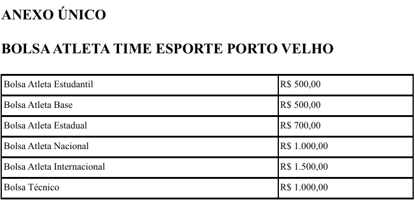